# Lab 5

# Part 1

```python
import pandas as pd
url = "https://www.dropbox.com/s/bocjjyo1ehr5auz/insurance_costs_1.csv?dl=1"

df = pd.read_csv(url)
df.head()
```

|  | age | sex | bmi | smoker | region | charges |
| --- | --- | --- | --- | --- | --- | --- |
| 0 | 19 | female | 27.900 | yes | southwest | 16884.92400 |
| 1 | 33 | male | 22.705 | no | northwest | 21984.47061 |
| 2 | 32 | male | 28.880 | no | northwest | 3866.85520 |
| 3 | 31 | female | 25.740 | no | southeast | 3756.62160 |
| 4 | 60 | female | 25.840 | no | northwest | 28923.13692 |

```python
df.describe()
```

|  | age | bmi | charges |
| --- | --- | --- | --- |
| count | 431.000000 | 431.000000 | 431.000000 |
| mean | 37.960557 | 30.768898 | 12297.098118 |
| std | 16.363909 | 6.111362 | 11876.527128 |
| min | 18.000000 | 15.960000 | 1131.506600 |
| 25% | 22.000000 | 26.357500 | 2710.444575 |
| 50% | 34.000000 | 30.590000 | 9866.304850 |
| 75% | 55.000000 | 35.272500 | 14510.872600 |
| max | 64.000000 | 49.060000 | 55135.402090 |

```python
df.isnull().sum()
```

```
age        0
sex        0
bmi        0
smoker     0
region     0
charges    0
dtype: int64
```

I do not have any concerns about the data

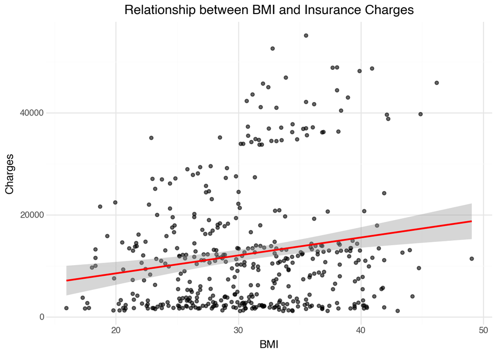

```python
from plotnine import *

(ggplot(df, aes(x="bmi", y="charges"))
    + geom_point(alpha=0.6)
    + geom_smooth(method="lm", color="red")
    + labs(
        title="Relationship between BMI and Insurance Charges",
        x="BMI",
        y="Charges"
    ) +
    theme_minimal()
)
```

This plot shows that as BMI incresaes, we also see a slight increase in Insurance costs.

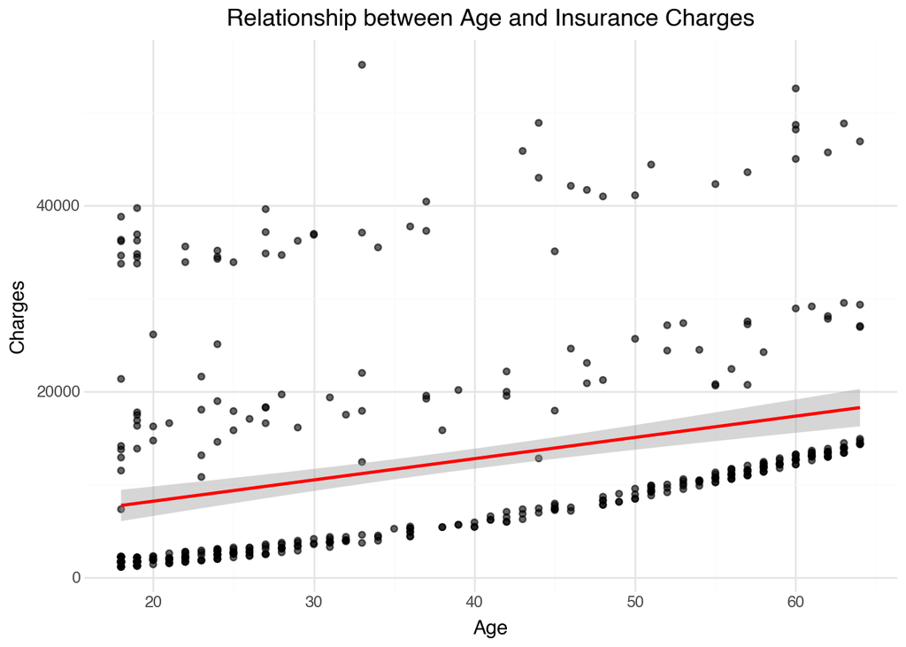

```python
(ggplot(df, aes(x="age", y="charges"))
    + geom_point(alpha=0.6)
    + geom_smooth(method="lm", color="red")
    + labs(
        title="Relationship between Age and Insurance Charges",
        x="Age",
        y="Charges"
    ) +
    theme_minimal()
)
```

This plot shows that as Age incresaes, we also see an increase in Insurance costs. This plot also shows that there appears to be a 3 distinct bands, potentally caused by number of insurance claims (0, 1, or 2). We can see that each distinct band increases with age basically linearly.

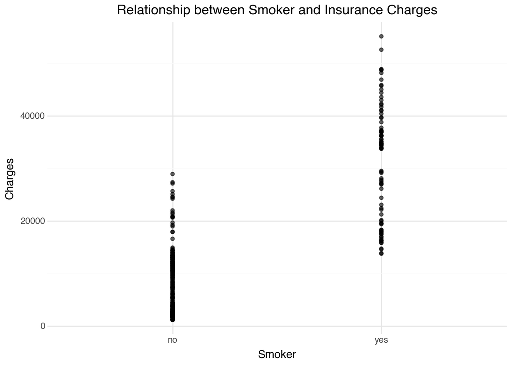

```python
(ggplot(df, aes(x="smoker", y="charges"))
    + geom_point(alpha=0.6)
    + labs(
        title="Relationship between Smoker and Insurance Charges",
        x="Smoker",
        y="Charges"
    ) +
    theme_minimal()
)
```

This plot shows that the average, minimum, and maximum charges for smokers are all higher than for non smokers.

# Part 2

## Q1

```python
from sklearn.linear_model import LinearRegression
from sklearn.metrics import mean_squared_error


model_age = LinearRegression()
model_age.fit(
    X=df[["age"]],
    y=df["charges"]
)

model_age.coef_, model_age.intercept_
```

```
(array([228.79904937]), np.float64(3611.758798507093))
```

```python
r2_age = model_age.score(df[["age"]], df["charges"])
r2_age
```

```
0.09938105452062695
```

```python
y_pred_age = model_age.predict(df[["age"]])

mse_age = mean_squared_error(df["charges"], y_pred_age)
```

The R^2 value of about 0.1 indicates that our model explains some of the variance, but not very much. The coefficient of 228 indicates that with an increase in age by 1, we predict the cost goes up by 228. The intercept of 3611 implies that if someone was 0 years old they would expect to have $3611 in charges.

## Q2

```python
df["sex_male"] = (df["sex"] == "male").astype(int)
```

```python
model_sex = LinearRegression()
model_sex.fit(
    X=df[["sex_male"]],
    y=df["charges"]
)

model_sex.coef_, model_sex.intercept_
```

```
(array([790.28862184]), np.float64(11919.373162039996))
```

```python
r2_sex = model_sex.score(df[["sex_male"]], df["charges"])
r2_sex
```

```
0.001107379656908658
```

The R^2 value of about 0 indicates that our model basically explains none of the variation. The coefficient of 790 indicates that a male will have an expected charges value of 790 more than female. This is essentially negligible considering we are thinking in terms of tens of thousands of dollars. The intercept of 11919 implies that if someone is a female (0 in our new df column) we would expect their charges to be $11919.

## Q3

```python
df["smoker_yes"] = (df["smoker"] == "yes").astype(int)
df
```

|  | age | sex | bmi | smoker | region | charges | sex_male | smoker_yes |
| --- | --- | --- | --- | --- | --- | --- | --- | --- |
| 0 | 19 | female | 27.900 | yes | southwest | 16884.92400 | 0 | 1 |
| 1 | 33 | male | 22.705 | no | northwest | 21984.47061 | 1 | 0 |
| 2 | 32 | male | 28.880 | no | northwest | 3866.85520 | 1 | 0 |
| 3 | 31 | female | 25.740 | no | southeast | 3756.62160 | 0 | 0 |
| 4 | 60 | female | 25.840 | no | northwest | 28923.13692 | 0 | 0 |
| ... | ... | ... | ... | ... | ... | ... | ... | ... |
| 426 | 23 | female | 33.400 | no | southwest | 10795.93733 | 0 | 0 |
| 427 | 18 | female | 31.920 | no | northeast | 2205.98080 | 0 | 0 |
| 428 | 18 | female | 36.850 | no | southeast | 1629.83350 | 0 | 0 |
| 429 | 21 | female | 25.800 | no | southwest | 2007.94500 | 0 | 0 |
| 430 | 61 | female | 29.070 | yes | northwest | 29141.36030 | 0 | 1 |

431 rows × 8 columns

```python
model_smoke = LinearRegression()
model_smoke.fit(
    X=df[["smoker_yes"]],
    y=df["charges"]
)

model_smoke.coef_, model_smoke.intercept_
```

```
(array([23623.90500127]), np.float64(7528.467642293576))
```

```python
r2_smoke = model_smoke.score(df[["smoker_yes"]], df["charges"])
r2_smoke
```

```
0.6389346108568914
```

The R^2 value of about 0.64 indicates that our model explains a considerable ammount of the variation. The coefficient of 23623 indicates that a smoker will have an expected charges value of 23623 more than a non-smoker. The intercept of 7528 implies that if someone is not a smoker, their expected charges is only $7528.

```python
from sklearn.metrics import mean_squared_error
import numpy as np

y_pred_smoke = model_smoke.predict(df[["smoker_yes"]])

mse_smoke = mean_squared_error(df["charges"], y_pred_smoke)

y_pred_sex = model_sex.predict(df[["sex_male"]])

mse_sex = mean_squared_error(df["charges"], y_pred_sex)
```

```python
print("Sex MSE: " + str(mse_sex))
print("Smoke MSE: " + str(mse_smoke))
print("Sex R2: " + str(r2_sex))
print("Smoke R2: " + str(r2_smoke))
```

```
Sex MSE: 140568794.44820437
Smoke MSE: 50810793.30767888
Sex R2: 0.001107379656908658
Smoke R2: 0.6389346108568914
```

Based on the smaller MSE and larger R2 we can conclude that the Model including Smoke is better than the one including sex.

# Part 3

```python
model_age_bmi = LinearRegression()
model_age_bmi.fit(
    X=df[["age", "bmi"]],
    y=df["charges"]
)

y_pred_age_bmi = model_age_bmi.predict(df[["age", "bmi"]])

mse_age_bmi = mean_squared_error(df["charges"], y_pred_age_bmi)

r2_age_bmi = model_age_bmi.score(df[["age", "bmi"]], df["charges"])

print("Age MSE: " + str(mse_age))
print("Age R2: " + str(r2_age))
print("Age and BMI as predictors MSE: " + str(mse_age_bmi))
print("Age and BMI as predictors R2: " + str(r2_age_bmi))
```

```
Age MSE: 126739267.9102639
Age R2: 0.09938105452062695
Age and BMI as predictors MSE: 123792439.58129103
Age and BMI as predictors R2: 0.12032144234129338
```

The model with age and the model with age and bmi are very similar. The MSE and R2 were both better for the model that included age and bmi

## Q2

```python
df["age_sqr"] = df["age"] ** 2

model_age_sqr = LinearRegression()
model_age_sqr.fit(
    X=df[["age", "age_sqr"]],
    y=df["charges"]
)

y_pred_age_sqr = model_age_sqr.predict(df[["age", "age_sqr"]])

mse_age_sqr = mean_squared_error(df["charges"], y_pred_age_sqr)

r2_age_sqr = model_age_sqr.score(df[["age", "age_sqr"]], df["charges"])

print("Age and Age^2 MSE: " + str(mse_age_sqr))
print("Age and Age^2 R2: " + str(r2_age_sqr))
```

```
Age and Age^2 MSE: 126710293.80956802
Age and Age^2 R2: 0.09958694669946933
```

The MSE and R2 was basically the same as in P2 Q1

## Q3

```python
from sklearn.preprocessing import PolynomialFeatures
poly = PolynomialFeatures(degree = 4, include_bias = False)
X_poly4 = poly.fit_transform(df[["age"]])

model_age_poly4 = LinearRegression()
model_age_poly4.fit(
    X = X_poly4,
    y = df["charges"]
)

y_pred_age_poly4 = model_age_poly4.predict(X_poly4)

mse_age_poly4 = mean_squared_error(df["charges"], y_pred_age_poly4)
r2_age_poly4 = model_age_poly4.score(X_poly4, df["charges"])

print("Age 4th degree MSE: " + str(mse_age_poly4))
print("Age 4th degree R2: " + str(r2_age_poly4))
```

```
Age 4th degree MSE: 125550389.64569828
Age 4th degree R2: 0.10782931453183786
```

MSE and R2 for this model are slighly better than in P2 Q1 but they are basically the same

## Q4

```python
poly = PolynomialFeatures(degree = 12, include_bias = False)
X_poly12 = poly.fit_transform(df[["age"]])

model_age_poly12 = LinearRegression()
model_age_poly12.fit(
    X = X_poly12,
    y = df["charges"]
)

y_pred_age_poly12 = model_age_poly12.predict(X_poly12)

mse_age_poly12 = mean_squared_error(df["charges"], y_pred_age_poly12)
r2_age_poly12 = model_age_poly12.score(X_poly12, df["charges"])

print("Age 12th degree MSE: " + str(mse_age_poly12))
print("Age 12th degree R2: " + str(r2_age_poly12))
```

```
Age 12th degree MSE: 125618485.56892939
Age 12th degree R2: 0.10734541968548872
```

MSE and R2 for this model are slighly better than in P2 Q1 but they are basically the same

## Q5

According to MSE and R2 the best model is P3 Q1 with a larger R2 and lower MSE. I do not think this is indeed the best model, I bet there are some other transformations or interactions that would produce a better model.

## Q6

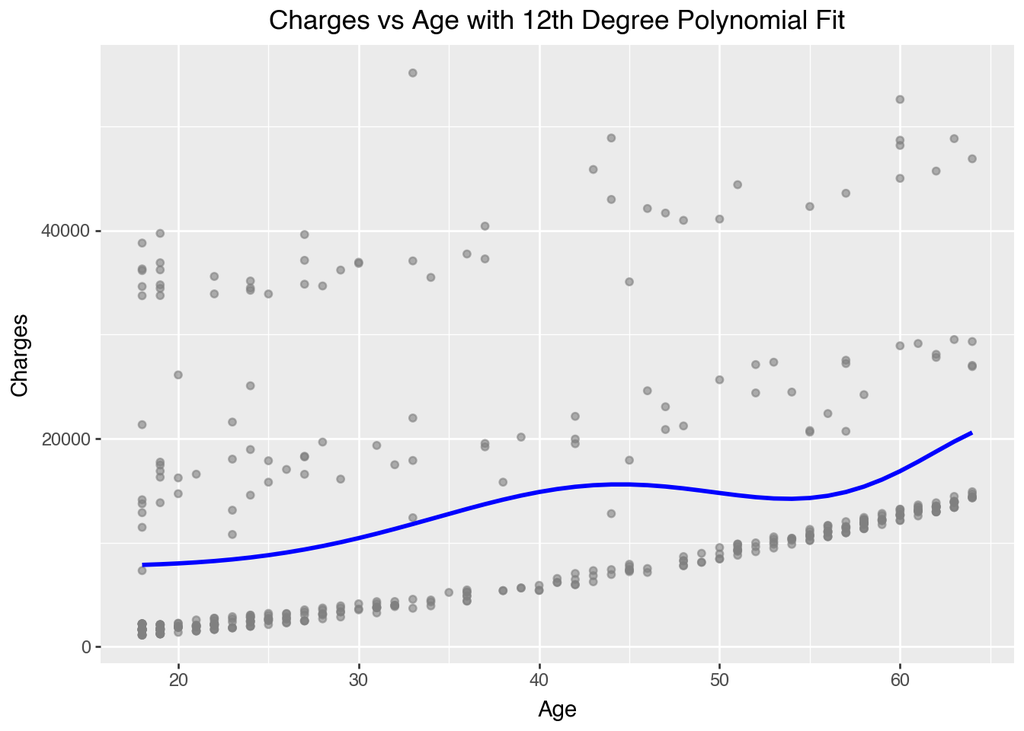

```python
(ggplot(df, aes(x="age", y="charges"))
    + geom_point(alpha=0.6, color="gray")
    + geom_line(aes(y="y_pred_age_poly12"), color="blue", size=1.2)
    + labs(
        title="Charges vs Age with 12th Degree Polynomial Fit",
        x="Age",
        y="Charges"
    )
)
```

# Part 4

```python
url_train = "https://www.dropbox.com/s/bocjjyo1ehr5auz/insurance_costs_1.csv?dl=1"

url_test = "https://www.dropbox.com/s/sky86agc4s8c6qe/insurance_costs_2.csv?dl=1"

df = pd.read_csv(url_train)
df_new = pd.read_csv(url_test)
df_new.head()
```

|  | age | sex | bmi | smoker | region | charges |
| --- | --- | --- | --- | --- | --- | --- |
| 0 | 23 | male | 34.400 | no | southwest | 1826.84300 |
| 1 | 56 | male | 40.300 | no | southwest | 10602.38500 |
| 2 | 18 | male | 34.100 | no | southeast | 1137.01100 |
| 3 | 63 | female | 23.085 | no | northeast | 14451.83515 |
| 4 | 63 | male | 28.310 | no | northwest | 13770.09790 |

```python
y_pred_age_new = model_age.predict(df_new[["age"]])
r2_age_new = model_age.score(df_new[["age"]], df_new["charges"])
mse_age_new = mean_squared_error(df_new["charges"], y_pred_age_new)

y_pred_age_bmi_new = model_age_bmi.predict(df_new[["age", "bmi"]])
r2_age_bmi_new = model_age_bmi.score(df_new[["age", "bmi"]], df_new["charges"])
mse_age_bmi_new = mean_squared_error(df_new["charges"], y_pred_age_new)

df["smoker_yes"] = (df["smoker"] == "yes").astype(int)
df_new["smoker_yes"] = (df_new["smoker"] == "yes").astype(int)


model_age_bmi_smoke = LinearRegression()
model_age_bmi_smoke.fit(
    X=df[["age", "bmi", "smoker_yes"]],
    y=df["charges"]
)

y_pred_age_bmi_smoke  = model_age_bmi_smoke.predict(df_new[["age", "bmi", "smoker_yes"]])

mse_age_bmi_smoke = mean_squared_error(df_new["charges"], y_pred_age_bmi_smoke)

r2_age_bmi = model_age_bmi_smoke.score(df_new[["age", "bmi", "smoker_yes"]], df_new["charges"])
```

```python
df["age_smoke"] = df["age"] * df["smoker_yes"]
df["bmi_smoke"] = df["bmi"] * df["smoker_yes"]

df_new["age_smoke"] = df_new["age"] * df_new["smoker_yes"]
df_new["bmi_smoke"] = df_new["bmi"] * df_new["smoker_yes"]

model_age__bmi_smoke_interact = LinearRegression()
model_age__bmi_smoke_interact.fit(
    X=df[["age_smoke", "bmi_smoke"]],
    y=df["charges"]
)

y_pred_age__bmi_smoke_interact = model_age__bmi_smoke_interact.predict(df_new[["age_smoke", "bmi_smoke"]])

mse_age__bmi_smoke_interact = mean_squared_error(df_new["charges"], y_pred_age__bmi_smoke_interact)

r2_age__bmi_smoke_interact = model_age__bmi_smoke_interact.score(df_new[["age_smoke", "bmi_smoke"]], df_new["charges"])

model_age_bmi_smoke_interact = LinearRegression()
model_age_bmi_smoke_interact.fit(
    X=df[["age", "bmi", "smoker_yes", "age_smoke", "bmi_smoke"]],
    y=df["charges"]
)

y_pred_age_bmi_smoke_interact = model_age_bmi_smoke_interact.predict(df_new[["age", "bmi", "smoker_yes", "age_smoke", "bmi_smoke"]])
mse_age_bmi_smoke_interact = mean_squared_error(df_new["charges"], y_pred_age_bmi_smoke_interact)

r2_age_bmi_smoke_interact = model_age_bmi_smoke_interact.score(df_new[["age", "bmi", "smoker_yes", "age_smoke", "bmi_smoke"]], df_new["charges"])

print("Age only MSE:  " + str(mse_age_new))
print("Age and bmi MSE:  " + str(mse_age_bmi_new))
print("Age, bmi, and smoker MSE:  " + str(mse_age_bmi_smoke))
print("Age_smoke and bmi_smoke MSE:  " + str(mse_age__bmi_smoke_interact))
print("Age, bmi, smoke, age_smoke, and bmi_smoke:  " + str(mse_age_bmi_smoke_interact))
```

```
Age only MSE:  136077136.50195494
Age and bmi MSE:  136077136.50195494
Age, bmi, and smoker MSE:  35377541.2414163
Age_smoke and bmi_smoke MSE:  47626025.358144134
Age, bmi, smoke, age_smoke, and bmi_smoke:  21786256.866852593
```

I got the model with age, bmi, and smokeras predictors, with both quantitative variables having an interaction term with smoker as the best model.

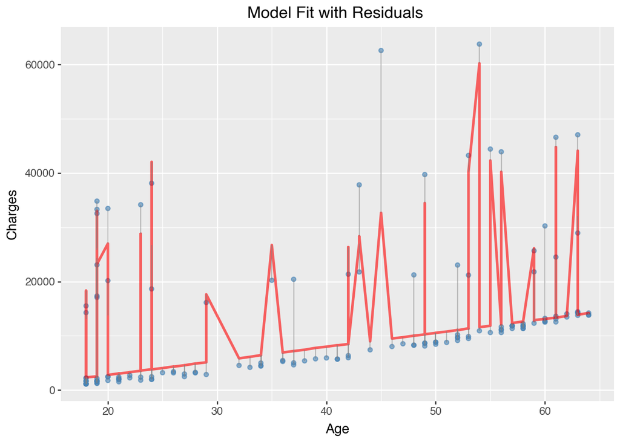

```python
df_new["predicted"] = model_age_bmi_smoke_interact.predict(df_new[["age", "bmi", "smoker_yes", "age_smoke", "bmi_smoke"]])

df_new = df_new.sort_values("age")

(ggplot(df_new, aes(x="age", y="charges"))
    + geom_point(color="steelblue", alpha=0.6)
    + geom_line(aes(y="predicted"), color="red", alpha=0.6, size=1.2)
    + geom_segment(
        aes(xend="age", yend="predicted"),
        color="gray", alpha=0.5
    )
    + labs(
        title="Model Fit with Residuals ",
        x="Age",
        y="Charges"
    )
)
```

# Part 5

```python
df["sex_male"] = (df["sex"] == "male").astype(int)
df_new["sex_male"] = (df_new["sex"] == "male").astype(int)
df["sex_male_smoke"] = df["sex_male"] * df["smoker_yes"]
df_new["sex_male_smoke"] = df_new["sex_male"] * df_new["smoker_yes"]


age_sex_bmi_smoke_interactions = LinearRegression()
age_sex_bmi_smoke_interactions.fit(
    X=df[["age", "bmi", "smoker_yes", "sex_male", "age_smoke", "bmi_smoke", "sex_male_smoke"]],
    y=df["charges"]
)

y_predage_sex_bmi_smoke_interactions = age_sex_bmi_smoke_interactions.predict(df_new[["age", "bmi", "smoker_yes", "sex_male", "age_smoke", "bmi_smoke", "sex_male_smoke"]])
mse_age_sex_bmi_smoke_interactions = mean_squared_error(df_new["charges"], y_predage_sex_bmi_smoke_interactions)

r2_age_sex_bmi_smoke_interactions = age_sex_bmi_smoke_interactions.score(df_new[["age", "bmi", "smoker_yes", "sex_male", "age_smoke", "bmi_smoke", "sex_male_smoke"]], df_new["charges"])

print("Variables: age, bmi, smoker, sex, age * smoke, bmi * smoke, sex * smoke MSE:  " + str(mse_age_sex_bmi_smoke_interactions))
print("Variables: age, bmi, smoker, sex, age * smoke, bmi * smoke, sex * smoke R2:  " + str(r2_age_sex_bmi_smoke_interactions))
```

```
Variables: age, bmi, smoker, sex, age * smoke, bmi * smoke, sex * smoke MSE:  21929570.18253059
Variables: age, bmi, smoker, sex, age * smoke, bmi * smoke, sex * smoke R2:  0.8585643747045506
```

```python
df["age_sqr"] = df["age"] ** 2
df_new["age_sqr"] = df_new["age"] ** 2



age_sex_bmi_smoke_interactions = LinearRegression()
age_sex_bmi_smoke_interactions.fit(
    X=df[["age", "bmi", "smoker_yes", "sex_male", "age_smoke", "bmi_smoke", "sex_male_smoke", "age_sqr"]],
    y=df["charges"]
)

y_predage_sex_bmi_smoke_interactions = age_sex_bmi_smoke_interactions.predict(df_new[["age", "bmi", "smoker_yes", "sex_male", "age_smoke", "bmi_smoke", "sex_male_smoke", "age_sqr"]])
mse_age_sex_bmi_smoke_interactions = mean_squared_error(df_new["charges"], y_predage_sex_bmi_smoke_interactions)

r2_age_sex_bmi_smoke_interactions = age_sex_bmi_smoke_interactions.score(df_new[["age", "bmi", "smoker_yes", "sex_male", "age_smoke", "bmi_smoke", "sex_male_smoke", "age_sqr"]], df_new["charges"])

print("Variables: age, bmi, smoker, sex, age * smoke, bmi * smoke, sex * smoke, age_sqr MSE:  " + str(mse_age_sex_bmi_smoke_interactions))
print("Variables: age, bmi, smoker, sex, age * smoke, bmi * smoke, sex * smoke, age_sqr R2:  " + str(r2_age_sex_bmi_smoke_interactions))
```

```
Variables: age, bmi, smoker, sex, age * smoke, bmi * smoke, sex * smoke, age_sqr MSE:  21828762.31090342
Variables: age, bmi, smoker, sex, age * smoke, bmi * smoke, sex * smoke, age_sqr R2:  0.8592145390369847
```

```python
age_sex_bmi_smoke_interactions = LinearRegression()
age_sex_bmi_smoke_interactions.fit(
    X=df[["age", "bmi", "smoker_yes", "sex_male", "age_smoke", "bmi_smoke", "age_sqr"]],
    y=df["charges"]
)

y_predage_sex_bmi_smoke_interactions = age_sex_bmi_smoke_interactions.predict(df_new[["age", "bmi", "smoker_yes", "sex_male", "age_smoke", "bmi_smoke", "age_sqr"]])
mse_age_sex_bmi_smoke_interactions = mean_squared_error(df_new["charges"], y_predage_sex_bmi_smoke_interactions)

r2_age_sex_bmi_smoke_interactions = age_sex_bmi_smoke_interactions.score(df_new[["age", "bmi", "smoker_yes", "sex_male", "age_smoke", "bmi_smoke",  "age_sqr"]], df_new["charges"])

print("Variables: age, bmi, smoker, sex, age * smoke, bmi * smoke, age_sqr MSE:  " + str(mse_age_sex_bmi_smoke_interactions))
print("Variables: age, bmi, smoker, sex, age * smoke, bmi * smoke, age_sqr R2:  " + str(r2_age_sex_bmi_smoke_interactions))
```

```
Variables: age, bmi, smoker, sex, age * smoke, bmi * smoke, age_sqr MSE:  21889452.35340498
Variables: age, bmi, smoker, sex, age * smoke, bmi * smoke, age_sqr R2:  0.8588231162211717
```

After trying many other models with many other variables and interactions, I found the model computed in the last part of part 4 with age, bmi, and smoker as predictors, with both quantitative variables having an interaction term with smoker to be the best model. Altough I was able to get close I could not beat the R2 of 0.85948 or the MSE of 21786256.

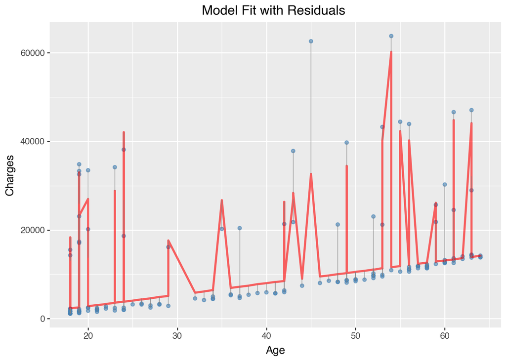

```python
(ggplot(df_new, aes(x="age", y="charges"))
    + geom_point(color="steelblue", alpha=0.6)
    + geom_line(aes(y="predicted"), color="red", alpha=0.6, size=1.2)
    + geom_segment(
        aes(xend="age", yend="predicted"),
        color="gray", alpha=0.5
    )
    + labs(
        title="Model Fit with Residuals ",
        x="Age",
        y="Charges"
    )
)
```